# Exercises-1

```python
%matplotlib inline
import pandas as pd
```

```python
from IPython.core.display import HTML
css = open('style-table.css').read() + open('style-notebook.css').read()
HTML('<style>{}</style>'.format(css))
```

```python
titles =  pd.read_csv('data/titles.csv')
titles.head()
```

|  | title | year |
| --- | --- | --- |
| 0 | Control | 2007 |
| 1 | Poi | 2006 |
| 2 | L'allegro fantasma | 1941 |
| 3 | Janghwa Heungryeonjeon | 1956 |
| 4 | Nochnaya smena | 1971 |

```python
cast = pd.read_csv('data/cast.csv')
```

### How many movies are listed in the titles dataframe?

```python
len(titles)
```

```
244914
```

### What are the earliest two films listed in the titles dataframe?

```python
titles.sort_values('year').head(2)
```

|  | title | year |
| --- | --- | --- |
| 226410 | Miss Jerry | 1894 |
| 242040 | The Startled Lover | 1898 |

### How many movies have the title "Hamlet"?

```python
#t = titles
#movies = t[t.title == 'Hamlet']
#len(movies)

len(titles[titles.title == 'Hamlet'])
```

```
20
```

### How many movies are titled "North by Northwest"?

```python
len(titles[titles.title == 'North by Northwest'])
```

```
1
```

### When was the first movie titled "Hamlet" made?

```python
titles[titles.title == 'Hamlet'].sort_values('year').head(1)
```

|  | title | year |
| --- | --- | --- |
| 12487 | Hamlet | 1910 |

### List all of the "Treasure Island" movies from earliest to most recent.

```python
titles[titles.title == 'Treasure Island'].sort_values('year')
```

|  | title | year |
| --- | --- | --- |
| 210706 | Treasure Island | 1918 |
| 187900 | Treasure Island | 1920 |
| 195347 | Treasure Island | 1934 |
| 18244 | Treasure Island | 1950 |
| 188913 | Treasure Island | 1972 |
| 127536 | Treasure Island | 1973 |
| 109106 | Treasure Island | 1985 |
| 202612 | Treasure Island | 1999 |

### How many movies were made in the year 1950?

```python
len(titles[titles.year == 1950])
```

```
1113
```

### How many movies were made in the year 1960?

```python
len(titles[titles.year == 1960])
```

```
1549
```

### How many movies were made from 1950 through 1959?

```python
len(titles[(titles.year >= 1950) & (titles.year <= 1959)])
```

```
12934
```

```python
len(titles[titles.year // 10 == 195])
```

```
12934
```

### In what years has a movie titled "Batman" been released?

```python
titles[titles.title == 'Batman'].year
```

```
138775    1989
140380    1943
Name: year, dtype: int64
```

### How many roles were there in the movie "Inception"?

```python
len(cast[cast.title == 'Inception'])
```

```
78
```

### How many roles in the movie "Inception" are NOT ranked by an "n" value?

```python
cast[(cast.title == 'Inception') & (cast.n.isnull())]
```

|  | title | year | name | type | character | n |
| --- | --- | --- | --- | --- | --- | --- |
| 98153 | Inception | 2010 | Michael (III) August | actor | LAX Passenger | NaN |
| 197877 | Inception | 2010 | Ken Bhan | actor | Mombasan Gambler | NaN |
| 374661 | Inception | 2010 | John Ceallach | actor | LAX Passenger | NaN |
| 497161 | Inception | 2010 | Garvin Cross | actor | Snow Commander | NaN |
| 684098 | Inception | 2010 | Seve Esposito | actor | Italian Gambler | NaN |
| 690634 | Inception | 2010 | Marcus (II) Everett | actor | Stock Broker | NaN |
| 707642 | Inception | 2010 | Zachary Christopher Fay | actor | Extra | NaN |
| 836295 | Inception | 2010 | Daniel Girondeaud | actor | Bridge Sub Con | NaN |
| 1006636 | Inception | 2010 | Andrew Hoagland | actor | Pedestrian | NaN |
| 1095095 | Inception | 2010 | Charles Jarrell | actor | Hotel Guest | NaN |
| 1108755 | Inception | 2010 | Seong-hwan Jo | actor | Japanese Landing Crew | NaN |
| 1120184 | Inception | 2010 | Alonzo F. Jones | actor | Mombasan Casino Staff | NaN |
| 1189066 | Inception | 2010 | Mobin Khan | actor | Mombasa Casino Cashier | NaN |
| 1248176 | Inception | 2010 | Shunsaku Kud? | actor | Saito's Bodyguard Officer | NaN |
| 1296268 | Inception | 2010 | John (IX) Lawson | actor | Street Person | NaN |
| 1312335 | Inception | 2010 | Jean-Christophe Leger | actor | French Student | NaN |
| 1665939 | Inception | 2010 | Fran?ois-Marie Nivon | actor | A Passer-By | NaN |
| 1836655 | Inception | 2010 | Scott Pretty | actor | Pedestrian | NaN |
| 1921209 | Inception | 2010 | Benjamin (II) Riley | actor | Bridge Sub Con | NaN |
| 1999736 | Inception | 2010 | Norman Saleet | actor | Airport Patron | NaN |
| 2127670 | Inception | 2010 | Colin (XXV) Smith | actor | Airport Patron | NaN |
| 2238386 | Inception | 2010 | Affan Tareen | actor | Denison | NaN |
| 2796449 | Inception | 2010 | Youlanda Davis | actress | Mombasan Cashier | NaN |
| 2852164 | Inception | 2010 | Julie Eagleton | actress | Stockbroker | NaN |
| 2950644 | Inception | 2010 | Natalie Goldwin | actress | LAX Passenger | NaN |
| 3054447 | Inception | 2010 | Marguerite Insolia | actress | Reporter | NaN |
| 3149397 | Inception | 2010 | Leticia LaBelle | actress | Airport Patron | NaN |

### But how many roles in the movie "Inception" did receive an "n" value?

```python
cast[(cast.title == 'Inception') & (cast.n.notnull())]
```

|  | title | year | name | type | character | n |
| --- | --- | --- | --- | --- | --- | --- |
| 149008 | Inception | 2010 | Peter Basham | actor | Fischer's Jet Captain | 44.0 |
| 183937 | Inception | 2010 | Tom Berenger | actor | Browning | 8.0 |
| 260128 | Inception | 2010 | Virgile Bramly | actor | Bridge Sub Con | 29.0 |
| 326745 | Inception | 2010 | Michael Caine | actor | Miles | 11.0 |
| 333415 | Inception | 2010 | Earl Cameron | actor | Elderly Bald Man | 20.0 |
| 433867 | Inception | 2010 | Nicolas Clerc | actor | Bridge Sub Con | 26.0 |
| 444385 | Inception | 2010 | Adam (IV) Cole | actor | Bar Sub Con | 34.0 |
| 517227 | Inception | 2010 | Jean-Michel Dagory | actor | Bridge Sub Con | 30.0 |
| 590576 | Inception | 2010 | Leonardo DiCaprio | actor | Cobb | 1.0 |
| 709436 | Inception | 2010 | Russ Fega | actor | Cab Driver | 23.0 |
| 737322 | Inception | 2010 | Mark Fleischmann | actor | Penrose Sub Con | 32.0 |
| 807795 | Inception | 2010 | Michael Gaston | actor | Immigration Officer | 45.0 |
| 812135 | Inception | 2010 | Johnathan Geare | actor | James (3 years) | 17.0 |
| 832083 | Inception | 2010 | Carl Gilliard | actor | Lobby Sub Con | 40.0 |
| 833376 | Inception | 2010 | Jack Gilroy | actor | Old Cobb | 50.0 |
| 859993 | Inception | 2010 | Joseph Gordon-Levitt | actor | Arthur | 2.0 |
| 910757 | Inception | 2010 | Lukas Haas | actor | Nash | 12.0 |
| 940923 | Inception | 2010 | Tom Hardy | actor | Eames | 4.0 |
| 967176 | Inception | 2010 | Ryan Hayward | actor | Lawyer | 21.0 |
| 1170785 | Inception | 2010 | Tim Kelleher | actor | Thin Man | 24.0 |
| 1309851 | Inception | 2010 | Tai-Li Lee | actor | Tadashi | 13.0 |
| 1455534 | Inception | 2010 | Tohoru Masamune | actor | Japanese Security Guard | 18.0 |
| 1615709 | Inception | 2010 | Cillian Murphy | actor | Robert Fischer | 7.0 |
| 1618527 | Inception | 2010 | Jack (III) Murray | actor | Bar Sub Con | 35.0 |
| 1668790 | Inception | 2010 | Magnus Nolan | actor | James (20 months) | 15.0 |
| 1701902 | Inception | 2010 | Yuji Okumoto | actor | Saito's Attendant | 19.0 |
| 1812091 | Inception | 2010 | Andrew Pleavin | actor | Businessman | 47.0 |
| 1826027 | Inception | 2010 | Pete Postlethwaite | actor | Maurice Fischer | 10.0 |
| 1861317 | Inception | 2010 | Marc Raducci | actor | Lobby Sub Con | 39.0 |
| 1876301 | Inception | 2010 | Dileep Rao | actor | Yusuf | 6.0 |
| 2049179 | Inception | 2010 | Felix Scott | actor | Businessman | 46.0 |
| 2250605 | Inception | 2010 | Jason Tendell | actor | Fischer's Driver | 49.0 |
| 2267383 | Inception | 2010 | Kraig Thornber | actor | Bar Sub Con | 36.0 |
| 2406531 | Inception | 2010 | Ken Watanabe | actor | Saito | 5.0 |
| 2614557 | Inception | 2010 | Natasha Beaumont | actress | Bar Sub Con | 38.0 |
| 2765969 | Inception | 2010 | Marion Cotillard | actress | Mal | 9.0 |
| 2776554 | Inception | 2010 | Helena Cullinan | actress | Penrose Sub Con | 31.0 |
| 2807441 | Inception | 2010 | Coralie Dedykere | actress | Bridge Sub Con | 27.0 |
| 2932657 | Inception | 2010 | Claire Geare | actress | Phillipa (3 years) | 14.0 |
| 2932664 | Inception | 2010 | Taylor Geare | actress | Phillipa (5 years) | 16.0 |
| 3151982 | Inception | 2010 | Silvie Laguna | actress | Bridge Sub Con | 28.0 |
| 3158892 | Inception | 2010 | Shelley Lang | actress | Penrose Sub Con | 33.0 |
| 3203564 | Inception | 2010 | Alex (II) Lombard | actress | Lobby Sub Con | 42.0 |
| 3225843 | Inception | 2010 | Jill Maddrell | actress | Lobby Sub Con | 41.0 |
| 3343512 | Inception | 2010 | Angela Nathenson | actress | Bar Sub Con | 37.0 |
| 3359825 | Inception | 2010 | Miranda Nolan | actress | Flight Attendant | 22.0 |
| 3387147 | Inception | 2010 | Ellen Page | actress | Ariadne | 3.0 |
| 3444628 | Inception | 2010 | Nicole Pulliam | actress | Lobby Sub Con | 43.0 |
| 3473041 | Inception | 2010 | Lisa (II) Reynolds | actress | Private Nurse | 48.0 |
| 3480170 | Inception | 2010 | Talulah Riley | actress | Blonde | 25.0 |
| 3731263 | Inception | 2010 | Shannon Welles | actress | Old Mal | 51.0 |

### Display the cast of "North by Northwest" in their correct "n"-value order, ignoring roles that did not earn a numeric "n" value.

```python
cast[(cast.title == 'North by Northwest') & (cast.n.notnull())].sort_values('n')
```

|  | title | year | name | type | character | n |
| --- | --- | --- | --- | --- | --- | --- |
| 871426 | North by Northwest | 1959 | Cary Grant | actor | Roger O. Thornhill | 1.0 |
| 3518333 | North by Northwest | 1959 | Eva Marie Saint | actress | Eve Kendall | 2.0 |
| 1457165 | North by Northwest | 1959 | James Mason | actor | Phillip Vandamm | 3.0 |
| 3157232 | North by Northwest | 1959 | Jessie Royce Landis | actress | Clara Thornhill | 4.0 |
| 356707 | North by Northwest | 1959 | Leo G. Carroll | actor | The Professor | 5.0 |
| 3048272 | North by Northwest | 1959 | Josephine Hutchinson | actress | Mrs. Townsend | 6.0 |
| 1695173 | North by Northwest | 1959 | Philip Ober | actor | Lester Townsend | 7.0 |
| 1275337 | North by Northwest | 1959 | Martin Landau | actor | Leonard | 8.0 |
| 2447081 | North by Northwest | 1959 | Adam Williams | actor | Valerian | 9.0 |
| 1811387 | North by Northwest | 1959 | Edward Platt | actor | Victor Larrabee | 10.0 |
| 665768 | North by Northwest | 1959 | Robert Ellenstein | actor | Licht | 11.0 |
| 2295714 | North by Northwest | 1959 | Les Tremayne | actor | Auctioneer | 12.0 |
| 464736 | North by Northwest | 1959 | Philip Coolidge | actor | Dr. Cross | 13.0 |
| 1508344 | North by Northwest | 1959 | Patrick McVey | actor | Sergeant Flamm | 14.0 |
| 206471 | North by Northwest | 1959 | Edward Binns | actor | Captain Junket | 15.0 |
| 1384780 | North by Northwest | 1959 | Ken Lynch | actor | Charley - Chicago Policeman | 16.0 |

### Display the entire cast, in "n"-order, of the 1972 film "Sleuth".

```python
cast[(cast.title == 'Sleuth') & (cast.year == 1972) & (cast.n.notnull())].sort_values('n')
```

|  | title | year | name | type | character | n |
| --- | --- | --- | --- | --- | --- | --- |
| 1705394 | Sleuth | 1972 | Laurence Olivier | actor | Andrew Wyke | 1.0 |
| 326773 | Sleuth | 1972 | Michael Caine | actor | Milo Tindle | 2.0 |
| 373876 | Sleuth | 1972 | Alec Cawthorne | actor | Inspector Doppler | 3.0 |
| 1465483 | Sleuth | 1972 | John (II) Matthews | actor | Detective Sergeant Tarrant | 4.0 |
| 2724553 | Sleuth | 1972 | Eve (III) Channing | actress | Marguerite Wyke | 5.0 |
| 1448690 | Sleuth | 1972 | Teddy Martin | actor | Police Constable Higgs | 6.0 |

### Now display the entire cast, in "n"-order, of the 2007 version of "Sleuth".

```python
cast[(cast.title == 'Sleuth') & (cast.year == 2007)].sort_values('n')
```

|  | title | year | name | type | character | n |
| --- | --- | --- | --- | --- | --- | --- |
| 326774 | Sleuth | 2007 | Michael Caine | actor | Andrew | 1.0 |
| 1293634 | Sleuth | 2007 | Jude Law | actor | Milo | 2.0 |
| 1805907 | Sleuth | 2007 | Harold Pinter | actor | Man on T.V. | 3.0 |
| 260242 | Sleuth | 2007 | Kenneth Branagh | actor | Other Man on T.V. | NaN |
| 373877 | Sleuth | 2007 | Alec (II) Cawthorne | actor | Inspector Doppler | NaN |
| 2724552 | Sleuth | 2007 | Eve (II) Channing | actress | Marguerite Wyke | NaN |
| 3370424 | Sleuth | 2007 | Carmel O'Sullivan | actress | Maggie | NaN |

### How many roles were credited in the silent 1921 version of Hamlet?

```python
len(cast[(cast.title == 'Hamlet') & (cast.year == 1921)])
```

```
9
```

### How many roles were credited in Branagh’s 1996 Hamlet?

```python
len(cast[(cast.title == 'Hamlet') & (cast.year == 1996)])
```

```
54
```

### How many "Hamlet" roles have been listed in all film credits through history?

```python
len(cast[(cast.character == 'Hamlet')])
```

```
96
```

### How many people have played an "Ophelia"?

```python
len(cast[(cast.character == 'Ophelia')].name.unique())
```

```
115
```

```python
%%time
cast[(cast.character == 'Ophelia')][['year', 'name']].sort_values('year')
```

```
Wall time: 460 ms
```

|  | year | name |
| --- | --- | --- |
| 3526621 | 1911 | Emilie Sannom |
| 2861126 | 1913 | Gertrude Elliot |
| 3231583 | 1917 | Helena Makowska |
| 3323802 | 1918 | Mrs. Priestly Morrison |
| 3062023 | 1921 | Lilly Jacobson |
| ... | ... | ... |
| 3247228 | 2017 | Bruna Marquezine |
| 3478641 | 2018 | Daisy Ridley |
| 3394170 | 2018 | Marie Paquim |
| 2894318 | 2018 | Petrina Fitzpatrick |
| 3004310 | 2018 | Malaak Hattab |

117 rows × 2 columns

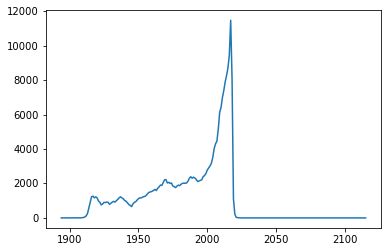

```python
titles.year.value_counts().sort_index().plot()
```

```python
titles
```

|  | title | year |
| --- | --- | --- |
| 0 | Control | 2007 |
| 1 | Poi | 2006 |
| 2 | L'allegro fantasma | 1941 |
| 3 | Janghwa Heungryeonjeon | 1956 |
| 4 | Nochnaya smena | 1971 |
| ... | ... | ... |
| 244909 | Chiens perdus sans collier | 1955 |
| 244910 | Internal Affairs | 2017 |
| 244911 | Princess Jones | 1921 |
| 244912 | Kshanbhar Vishranti | 2010 |
| 244913 | All Around the World: Jermaine Jones | 2013 |

244914 rows × 2 columns

### How many people have played a role called "The Stranger"?

### How many roles has Sidney Poitier played throughout his career?

### How many roles has Judi Dench played?

### List the supporting roles (having n=2) played by Cary Grant in the 1940s, in order by year.

### List the leading roles that Cary Grant played in the 1940s in order by year.

### How many roles were available for actors in the 1950s?

### How many roles were available for actresses in the 1950s?

### How many leading roles (n=1) were available from the beginning of film history through 1980?

### How many non-leading roles were available through from the beginning of film history through 1980?

### How many roles through 1980 were minor enough that they did not warrant a numeric "n" rank?